# Validación de las anotaciones LLM: Luna-6 y Haiku 5.5 frente a la referencia humana ciega

Este reporte compara los censos de Luna-6 (`gpt-6-luna`) y Claude Haiku 5.5 con la codificación manual ciega de 360 bloques, y respalda la sección de validación del manuscrito. Sigue las decisiones de `docs/decisiones-validacion.md`: métricas generales, elección del modelo y concordancia por grupo en el texto principal, y una tabla por concepto en el material suplementario. Todas las métricas son sin ponderar.

La codificación humana es una referencia humana ciega de una sola persona, no un *gold standard*: F1, precisión y sensibilidad miden acuerdo con esa referencia y no exactitud.

## Seteo de la sesión

Cargamos los paquetes, el helper de tablas APA 7 y las rutas de entrada. `irr` calcula el alfa de Krippendorff y el kappa de Cohen; `yardstick`, F1, precisión y sensibilidad; `ggplot2`, el gráfico. Los intervalos de confianza se estiman remuestreando bloques con una semilla fija.

**Código**

```r
pacman::p_load(arrow, dplyr, tidyr, purrr, jsonlite, ggplot2,
               yardstick, irr, flextable, officer)
source("R/apa7_word_table.R")

SESSION_PATH <- "output/validation/validation_20261004T182304711670Z_1c31732c.json"
LUNA_DIR <- "output/annotations/openai_gpt6luna_20261002"
HAIKU_DIR <- "output/annotations/bedrock_haiku55_20261008"
CODEBOOK_PATH <- "data/proc_data/annotations_inputs/pilot_d4e0291b4df3fc0f5343/codebook.json"
TABLE_DIR <- "output/tables/validation"
FIGURE_DIR <- "output/figures/validation"
SEED <- 20261009
ALPHA_MINIMO <- 0.667
dir.create(TABLE_DIR, recursive = TRUE, showWarnings = FALSE)
dir.create(FIGURE_DIR, recursive = TRUE, showWarnings = FALSE)

abreviaturas <- c(
  capitalizacion_individual = "Capitalización", propiedad_individual_fondos = "Propiedad",
  reciprocidad_contributiva = "Reciprocidad", control_responsabilidad_individual = "Control",
  actitud = "Actitud", identidad = "Identidad", necesidad_material = "Necesidad",
  igualdad_universalismo = "Igualdad", conciencia_costos = "Costos",
  solidaridad_previsional_colectiva = "Solidaridad colectiva",
  solidaridad_intergeneracional = "Solidaridad intergeneracional",
  libertad_eleccion_previsional = "Libertad de elección", ineficiencia_estado = "Ineficiencia estatal",
  prevision_como_mercado = "Mercado", ilegitimidad_origen_dictatorial = "Ilegitimidad dictatorial",
  acuerdos_moderacion = "Acuerdos"
)
```

Leemos la sesión manual y conservamos todos los bloques con decisión humana, incluidos los de votación o contenido procedimental: son acuerdos genuinos sobre bloques sin justificaciones normativas. Queda fuera solo el bloque irresoluble, que no tiene decisión humana. Las anotaciones de los modelos se leen de los `annotations.parquet` de cada censo.

**Código**

```r
concepts <- as_tibble(fromJSON(CODEBOOK_PATH)$concepts) |>
  select(concept_id = id, concepto = label)
stopifnot(setequal(names(abreviaturas), concepts$concept_id))
items <- as_tibble(fromJSON(SESSION_PATH)$items)

blocks <- items |>
  filter(!is.na(decision)) |>
  select(unit_id, law_number, decision)
human <- items |>
  filter(!is.na(decision)) |>
  select(unit_id, annotations) |>
  unnest(annotations) |>
  select(unit_id, concept_id, stance)

model_columns <- c("unit_id", "concept_id", "stance")
coders <- bind_rows(
  humano = human,
  luna = read_parquet(file.path(LUNA_DIR, "annotations.parquet"), col_select = all_of(model_columns)),
  haiku = read_parquet(file.path(HAIKU_DIR, "annotations.parquet"), col_select = all_of(model_columns)),
  .id = "codificador"
)
results <- bind_rows(
  luna = read_parquet(file.path(LUNA_DIR, "results.parquet"), col_select = c(unit_id, status, decision)),
  haiku = read_parquet(file.path(HAIKU_DIR, "results.parquet"), col_select = c(unit_id, status, decision)),
  .id = "codificador"
)
stopifnot(nrow(blocks) == 359,
          all(results$status == "completed"),
          all(blocks$unit_id %in% results$unit_id),
          all(human$concept_id %in% concepts$concept_id))
```

Los metadatos del hablante proceden del corpus procesado y se unen por `unit_id`; la ley se toma de la sesión. El género faltante queda como «Sin dato»; la alineación usa `political_alignment`, derivada del grupo político en la fecha del debate.

**Código**

```r
meta <- map_dfr(c("21419", "21538", "21735"), \(law) read_parquet(
  sprintf("data/proc_data/ley_%s/coding_chunks_long.parquet", law),
  col_select = c(unit_id, gender, political_alignment)
)) |>
  inner_join(select(blocks, unit_id, law_number), by = "unit_id") |>
  transmute(
    unit_id,
    ley = factor(paste0("Ley ", substr(law_number, 1, 2), ".", substr(law_number, 3, 5))),
    genero = factor(coalesce(gender, "Sin dato"), levels = c("hombre", "mujer", "Sin dato"),
                    labels = c("Hombre", "Mujer", "Sin dato")),
    alineacion = factor(political_alignment, levels = c("izquierda", "centro", "derecha", "nonpartisan"),
                        labels = c("Izquierda", "Centro", "Derecha", "No partidista"))
  )
stopifnot(nrow(meta) == nrow(blocks))
```

Construimos las rejillas de comparación. En **detección**, la unidad es el bloque y el valor indica si tiene declaraciones. En **concepto**, la unidad es bloque × concepto (16 por bloque) y el valor indica si el codificador asignó el concepto, con cualquier postura. En **concepto y postura**, la unidad es bloque × concepto × postura. La comparación de conjuntos por bloque no usa el solapamiento de las citas.

**Código**

```r
presence <- function(keys) {
  coders |>
    distinct(codificador, unit_id, across(all_of(keys))) |>
    mutate(valor = 1L) |>
    pivot_wider(names_from = codificador, values_from = valor, values_fill = 0L)
}

detection_grid <- blocks |>
  transmute(unit_id, humano = as.integer(decision == "statements")) |>
  left_join(results |>
              transmute(codificador, unit_id, valor = as.integer(decision == "statements")) |>
              pivot_wider(names_from = codificador, values_from = valor),
            by = "unit_id")
concept_grid <- blocks |>
  select(unit_id) |>
  cross_join(select(concepts, concept_id)) |>
  left_join(presence("concept_id"), by = c("unit_id", "concept_id")) |>
  mutate(across(c(humano, luna, haiku), \(x) coalesce(x, 0L)))
stance_grid <- blocks |>
  select(unit_id) |>
  cross_join(expand_grid(concept_id = concepts$concept_id, stance = c("support", "oppose"))) |>
  left_join(presence(c("concept_id", "stance")), by = c("unit_id", "concept_id", "stance")) |>
  mutate(across(c(humano, luna, haiku), \(x) coalesce(x, 0L)))
```

Definimos las piezas que se reutilizan. `alfa()` calcula el α nominal de Krippendorff para dos o tres codificadores; `f1()`, el F1 de un par, que con dos codificadores equivale al acuerdo específico positivo. `bootstrap()` remuestrea bloques con reposición y calcula en cada réplica el α humano–Luna y el α humano–Haiku, de modo que también estima la diferencia entre ambos. `tabla()` exporta una tabla a Word con el estilo APA 7 y la muestra aquí; `val()` y `ic()` dan formato a las cifras que se citan en el texto.

**Código**

```r
alfa <- function(grid, coders) kripp.alpha(t(as.matrix(grid[coders])), method = "nominal")$value
f1 <- function(grid, a, b) f_meas_vec(factor(grid[[a]], levels = 1:0), factor(grid[[b]], levels = 1:0))

bootstrap <- function(grid, reps) {
  ids <- unique(grid$unit_id)
  map_dfr(seq_len(reps), \(r) {
    muestra <- inner_join(tibble(unit_id = sample(ids, replace = TRUE)), grid,
                          by = "unit_id", relationship = "many-to-many")
    tibble(luna = alfa(muestra, c("humano", "luna")), haiku = alfa(muestra, c("humano", "haiku")))
  })
}

num <- function(x, digits = 2) formatC(x, format = "f", digits = digits, decimal.mark = ",")
val <- function(data, ..., col, digits = 2) {
  x <- filter(data, ...)[[col]]
  stopifnot(length(x) == 1)
  num(x, digits)
}
ic <- function(estimate, inf, sup) paste0(num(estimate), " [", num(inf), "–", num(sup), "]")
miles <- function(x) formatC(x, format = "d", big.mark = ".", decimal.mark = ",")
lista <- function(x) if (length(x) == 1) x else paste(paste(head(x, -1), collapse = ", "), "y", tail(x, 1))

tabla <- function(data, file, number, title, note, landscape = FALSE) {
  data <- mutate(data,
                 across(where(is.double), \(x) if_else(is.na(x), "", num(x))),
                 across(where(is.integer), \(x) formatC(x, format = "d", big.mark = ".", decimal.mark = ",")))
  export_apa7_word_table(data, file.path(TABLE_DIR, file), title, note,
                         table_number = number, landscape = landscape)
  flextable(data) |>
    theme_apa() |>
    set_caption(paste0("Tabla ", number, ". ", title)) |>
    add_footer_lines(as_paragraph(as_i("Nota."), paste0(" ", note))) |>
    autofit() |>
    htmltools_value()
}
```

## Métricas generales

Calculamos las métricas que resume el texto principal: α y F1 en la tarea de concepto para los pares humano–Luna, humano–Haiku y Luna–Haiku; α en la tarea de concepto y postura; el acuerdo específico negativo, 2d/(2d + b + c), espejo de F1 en las ausencias; la concordancia de postura entre los pares bloque–concepto que la referencia y el modelo asignan; y, en la tarea de detección, la proporción de bloques sin justificaciones para la referencia en que el modelo identifica alguna.

**Código**

```r
pares <- list(luna = c("humano", "luna"), haiku = c("humano", "haiku"), modelos = c("luna", "haiku"))
generales <- imap_dfr(pares, \(p, nombre) tibble(
  par = nombre,
  alfa_concepto = alfa(concept_grid, p),
  alfa_postura = alfa(stance_grid, p),
  f1_concepto = f1(concept_grid, p[1], p[2]),
  negativo = 2 * sum(!concept_grid[[p[1]]] & !concept_grid[[p[2]]]) /
    (2 * sum(!concept_grid[[p[1]]] & !concept_grid[[p[2]]]) + sum(concept_grid[[p[1]]] != concept_grid[[p[2]]]))
))

postura <- coders |>
  group_by(codificador, unit_id, concept_id) |>
  summarise(posturas = paste(sort(unique(stance)), collapse = "+"), .groups = "drop") |>
  pivot_wider(names_from = codificador, values_from = posturas) |>
  filter(unit_id %in% blocks$unit_id) |>
  pivot_longer(c(luna, haiku), names_to = "par", values_to = "prediccion") |>
  filter(!is.na(humano), !is.na(prediccion)) |>
  group_by(par) |>
  summarise(concordancia = mean(humano == prediccion))

frontera <- detection_grid |>
  filter(humano == 0) |>
  pivot_longer(c(luna, haiku), names_to = "par", values_to = "modelo") |>
  left_join(concept_grid |>
              pivot_longer(c(luna, haiku), names_to = "par", values_to = "asignado") |>
              group_by(unit_id, par) |>
              summarise(conceptos = sum(asignado), .groups = "drop"),
            by = c("unit_id", "par")) |>
  group_by(par) |>
  summarise(bloques = n(), con_concepto = sum(modelo), proporcion = mean(modelo),
            conceptos = mean(conceptos[modelo == 1]))
```

En la tarea de concepto, la concordancia con la referencia es casi igual para ambos modelos: α de 0,68 con Luna y 0,69 con Haiku, y F1 de 0,71 y 0,72. Agregar la postura casi no cambia el α (0,68 y 0,69): cuando coinciden en el concepto, coinciden también en la postura en 0,979 (Luna) y 0,976 (Haiku) de los casos. Son valores del mismo orden que los de estudios de referencia con GPT-4 y Gemini (κ medio de 0,68 en Dunivin, 2025; α medio de 0,65 en Bosley, 2025). Los dos modelos concuerdan más entre sí (0,82) que con la referencia: el instrumento es estable entre modelos, pero ese acuerdo mutuo no es evidencia de validez.

El desacuerdo es asimétrico. Por celda, los modelos casi no asignan conceptos ausentes en la referencia: el acuerdo específico negativo es 0,97 con Luna, frente a 0,71 del positivo. Por bloque, el desacuerdo se concentra en la frontera entre descripción y justificación normativa: de los 77 bloques sin justificaciones para la referencia, Luna identifica alguna en 31 (40 %), casi siempre un solo concepto (1,3 en promedio).

## Elección del modelo

Estimamos, con 10.000 remuestreos de bloques, el α humano–Luna y el α humano–Haiku en el agregado y por concepto, junto con la diferencia entre ambos. La regla de inclusión excluye un concepto solo si todo su intervalo con el modelo principal queda bajo 0,667. Contamos además las anotaciones de cada modelo en el censo de 3.609 bloques.

**Código**

```r
set.seed(SEED)
boot_agregado <- bootstrap(concept_grid, reps = 10000)
boot_conceptos <- concept_grid |>
  filter(concept_id %in% human$concept_id) |>
  nest(.by = concept_id) |>
  mutate(boot = map(data, \(g) bootstrap(g, reps = 10000))) |>
  select(concept_id, boot)
```

**Código**

```r
q <- function(x, p) unname(quantile(x, p, na.rm = TRUE))
agregado <- tibble(diferencia = alfa(concept_grid, c("humano", "haiku")) - alfa(concept_grid, c("humano", "luna")),
                   inf = q(boot_agregado$haiku - boot_agregado$luna, 0.025),
                   sup = q(boot_agregado$haiku - boot_agregado$luna, 0.975))

por_concepto <- concept_grid |>
  filter(concept_id %in% human$concept_id) |>
  nest(.by = concept_id) |>
  mutate(n = map_int(data, \(g) sum(g$humano)),
         alfa_luna = map_dbl(data, \(g) alfa(g, c("humano", "luna"))),
         alfa_haiku = map_dbl(data, \(g) alfa(g, c("humano", "haiku"))),
         alfa_modelos = map_dbl(data, \(g) alfa(g, c("luna", "haiku"))),
         alfa_tres = map_dbl(data, \(g) alfa(g, c("humano", "luna", "haiku"))),
         precision = map_dbl(data, \(g) precision_vec(factor(g$humano, 1:0), factor(g$luna, 1:0))),
         sensibilidad = map_dbl(data, \(g) recall_vec(factor(g$humano, 1:0), factor(g$luna, 1:0))),
         f1 = map_dbl(data, \(g) f1(g, "humano", "luna")),
         kappa = map_dbl(data, \(g) kappa2(as.matrix(g[c("humano", "luna")]))$value)) |>
  select(-data) |>
  left_join(boot_conceptos, by = "concept_id") |>
  mutate(luna_inf = map_dbl(boot, \(b) q(b$luna, 0.025)), luna_sup = map_dbl(boot, \(b) q(b$luna, 0.975)),
         haiku_inf = map_dbl(boot, \(b) q(b$haiku, 0.025)), haiku_sup = map_dbl(boot, \(b) q(b$haiku, 0.975)),
         dif_inf = map_dbl(boot, \(b) q(b$haiku - b$luna, 0.025)),
         dif_sup = map_dbl(boot, \(b) q(b$haiku - b$luna, 0.975)),
         diferencia_clara = dif_inf > 0 | dif_sup < 0,
         incluido_luna = luna_sup >= ALPHA_MINIMO,
         incluido_haiku = haiku_sup >= ALPHA_MINIMO,
         abreviatura = abreviaturas[concept_id]) |>
  select(-boot) |>
  arrange(desc(n))
arrow::write_parquet(por_concepto, file.path(TABLE_DIR, "concordancia_por_concepto.parquet"))

# Conceptos de los repertorios de H1a, H1b y H3: la regla no debe excluirlos sin advertirlo.
conceptos_hipotesis <- c("propiedad_individual_fondos", "capitalizacion_individual",
                         "reciprocidad_contributiva", "conciencia_costos", "ineficiencia_estado",
                         "prevision_como_mercado", "igualdad_universalismo",
                         "solidaridad_intergeneracional", "necesidad_material")
excluidos <- por_concepto |> filter(!incluido_luna) |> left_join(concepts, by = "concept_id")
stopifnot(!any(excluidos$concept_id %in% conceptos_hipotesis))
fronterizos <- por_concepto |>
  filter(incluido_luna, abs(luna_sup - ALPHA_MINIMO) < 0.02) |>
  left_join(concepts, by = "concept_id")

censo <- coders |>
  filter(codificador != "humano") |>
  group_by(codificador) |>
  summarise(bloques = n_distinct(unit_id), asignaciones = n_distinct(paste(unit_id, concept_id)))
```

La figura compara, para los 15 conceptos evaluables, el α de la referencia con cada modelo y su intervalo del 95 %. Los conceptos se separan entre los que sostienen hipótesis y los demás, y se ordenan por el α con Luna; la etiqueta indica el número de fragmentos con el concepto en la referencia.

**Código**

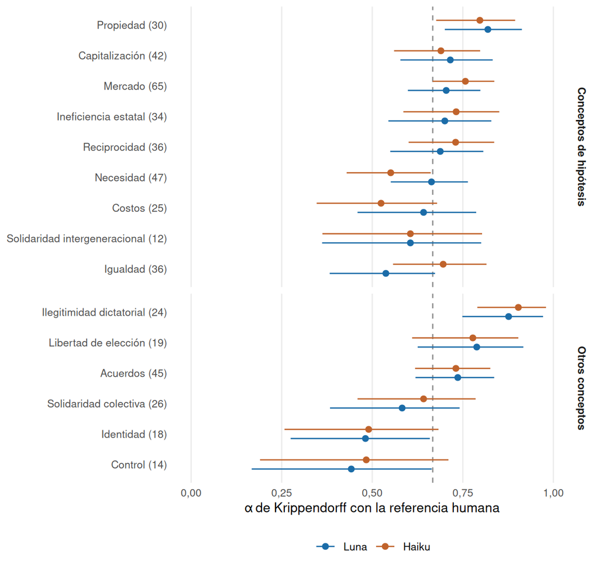

Figura 1: Concordancia entre la referencia humana y cada modelo (α de Krippendorff) por concepto, con intervalos de confianza del 95 % (10.000 remuestreos). La línea discontinua marca 0,667.

```r
conceptos_figura <- por_concepto |>
  mutate(grupo = factor(if_else(concept_id %in% conceptos_hipotesis, "Conceptos de hipótesis", "Otros conceptos")),
         etiqueta = reorder(paste0(abreviatura, " (", n, ")"), alfa_luna))
figura_conceptos <- bind_rows(
  Luna = transmute(conceptos_figura, grupo, etiqueta, alfa = alfa_luna, inf = luna_inf, sup = luna_sup),
  Haiku = transmute(conceptos_figura, grupo, etiqueta, alfa = alfa_haiku, inf = haiku_inf, sup = haiku_sup),
  .id = "modelo"
) |>
  mutate(modelo = factor(modelo, levels = c("Luna", "Haiku"))) |>
  ggplot(aes(x = alfa, xmin = inf, xmax = sup, y = etiqueta, colour = modelo)) +
  geom_vline(xintercept = ALPHA_MINIMO, linetype = "dashed", colour = "grey55") +
  geom_pointrange(position = position_dodge(width = 0.6), size = 0.3) +
  facet_grid(grupo ~ ., scales = "free_y", space = "free_y") +
  scale_colour_manual(values = c(Luna = "#1b6ca8", Haiku = "#c0632b")) +
  scale_x_continuous(limits = c(0, 1), labels = \(x) format(x, decimal.mark = ",")) +
  labs(x = "α de Krippendorff con la referencia humana", y = NULL, colour = NULL) +
  theme_minimal(base_size = 10) +
  theme(legend.position = "bottom", panel.grid.minor = element_blank(),
        panel.grid.major.y = element_blank(), strip.text.y = element_text(face = "bold"))
ggsave(file.path(FIGURE_DIR, "concordancia_por_concepto.png"), figura_conceptos,
       width = 6.3, height = 6, dpi = 300, bg = "white")
figura_conceptos
```

En el agregado, los modelos no difieren: el α de Haiku supera al de Luna en 0,01 (IC 95 % -0,02 a 0,04). Por concepto, la diferencia es clara solo en 3 de 15 conceptos: Luna concuerda mejor en necesidad material (0,66 frente a 0,55) y en conciencia de costos (0,64 frente a 0,52), y Haiku en igualdad y universalismo (0,70 frente a 0,54). Elegir el mejor modelo en cada concepto sobreestimaría el desempeño, porque la misma muestra serviría para elegir y para reportar. Por eso se usa un modelo principal para todo el corpus.

Luna-6 es el modelo principal. Necesidad material es el concepto central de H1b, y con Haiku la regla de inclusión lo excluiría (su intervalo termina en 0,66). Con Luna, la regla excluye identidad y control (intervalos hasta 0,659 y 0,664), que no sostienen ninguna hipótesis. Entre los conceptos incluidos, igualdad queda cerca del umbral (0,673). `actitud` no es evaluable, porque la referencia no lo asigna. En el censo, Haiku anota más: 3.237 asignaciones bloque × concepto frente a 2.717 de Luna (19 % más), sobre todo en capitalización individual y en las dos formas de solidaridad. Haiku reproduce los análisis principales en el material suplementario.

## Concordancia por grupo

Estimamos el α humano–Luna dentro de cada grupo de ley, género y alineación política, con intervalos de confianza por remuestreo de bloques dentro del grupo (1.000 réplicas). La pregunta es si los errores del modelo principal se concentran en algún grupo, lo que sesgaría la red.

**Código**

```r
set.seed(SEED)
group_levels <- c(levels(meta$ley), levels(meta$genero), levels(meta$alineacion))
grupos <- concept_grid |>
  left_join(meta, by = "unit_id") |>
  mutate(across(c(ley, genero, alineacion), as.character)) |>
  pivot_longer(c(ley, genero, alineacion), names_to = "variable", values_to = "grupo") |>
  nest(.by = c(variable, grupo)) |>
  mutate(bloques = map_int(data, \(g) n_distinct(g$unit_id)),
         alfa = map_dbl(data, \(g) alfa(g, c("humano", "luna"))),
         boot = map(data, \(g) bootstrap(g, reps = 1000)),
         inf = map_dbl(boot, \(b) quantile(b$luna, 0.025, na.rm = TRUE)),
         sup = map_dbl(boot, \(b) quantile(b$luna, 0.975, na.rm = TRUE))) |>
  transmute(variable = factor(variable, levels = c("ley", "genero", "alineacion"),
                              labels = c("Ley", "Género", "Alineación política")),
            grupo = factor(grupo, levels = group_levels), bloques, alfa, inf, sup)
arrow::write_parquet(grupos, file.path(TABLE_DIR, "concordancia_por_grupo.parquet"))
```

**Código**

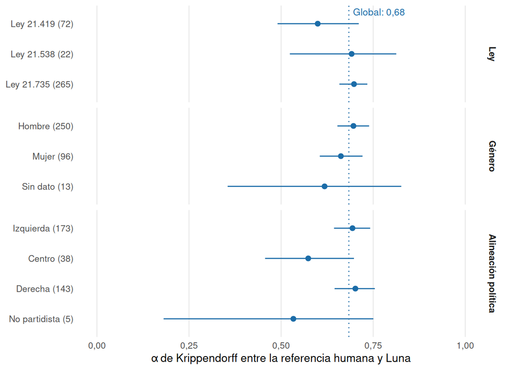

Figura 2: Concordancia entre la referencia humana y Luna-6 (α de Krippendorff) por ley, género y alineación política, con intervalos de confianza del 95 %. La línea punteada marca la concordancia global.

```r
# Exported at the usable page width (6.3 in), so Word inserts it at true size.
alfa_global <- generales$alfa_concepto[generales$par == "luna"]
figura_grupos <- grupos |>
  arrange(variable, desc(grupo)) |>
  mutate(etiqueta = factor(paste0(grupo, " (", bloques, ")"),
                           levels = unique(paste0(grupo, " (", bloques, ")")))) |>
  ggplot(aes(x = alfa, xmin = inf, xmax = sup, y = etiqueta)) +
  geom_vline(xintercept = alfa_global, linetype = "dotted", colour = "#1b6ca8") +
  # Label the overall line once, in the top panel only.
  geom_text(data = tibble(variable = factor("Ley", levels = levels(grupos$variable))),
            aes(x = alfa_global, y = Inf,
                label = paste("Global:", format(round(alfa_global, 2), nsmall = 2, decimal.mark = ","))),
            inherit.aes = FALSE, hjust = -0.08, vjust = 1.4, size = 3, colour = "#1b6ca8") +
  geom_pointrange(colour = "#1b6ca8", size = 0.3) +
  facet_grid(variable ~ ., scales = "free_y", space = "free_y") +
  scale_x_continuous(limits = c(0, 1), labels = \(x) format(x, decimal.mark = ",")) +
  labs(x = "α de Krippendorff entre la referencia humana y Luna", y = NULL) +
  theme_minimal(base_size = 10) +
  theme(panel.grid.minor = element_blank(), panel.grid.major.y = element_blank(),
        strip.text.y = element_text(face = "bold"))
ggsave(file.path(FIGURE_DIR, "concordancia_por_grupo.png"), figura_grupos,
       width = 6.3, height = 4.6, dpi = 300, bg = "white")
figura_grupos
```

La concordancia es similar entre izquierda y derecha (0,69 y 0,70) y entre hombres y mujeres (0,70 y 0,66). Es menor en la Ley 21.419 (0,60, frente a 0,70 en la Ley 21.735) y en el centro político (0,57), pero sus intervalos se solapan con los de los demás grupos. No hay evidencia de que los errores se concentren de forma sistemática en un grupo político. Los grupos pequeños (Ley 21.538, hablantes sin dato de género y no partidistas) tienen intervalos demasiado amplios para interpretarlos.

## Material suplementario

### Concordancia por concepto

La tabla reúne, por concepto, las métricas del par humano–Luna (precisión, sensibilidad, F1 y kappa de Cohen), el α humano–Luna y humano–Haiku con su intervalo del 95 %, el α entre modelos y el α de los tres codificadores. Muestra a la vez la sensibilidad de α a la combinación de codificadores y la comparación que justifica elegir Luna.

**Código**

```r
por_concepto |>
  transmute(Concepto = if_else(incluido_luna, abreviatura, paste0(abreviatura, "*")),
            n, P = precision, S = sensibilidad, F1 = f1, `κ` = kappa,
            `α H–L [IC 95 %]` = ic(alfa_luna, luna_inf, luna_sup),
            `α H–Hk [IC 95 %]` = ic(alfa_haiku, haiku_inf, haiku_sup),
            `α L–Hk` = alfa_modelos, `α tres` = alfa_tres) |>
  tabla("tS1_concordancia_por_concepto.docx", "S1",
        "Concordancia entre la referencia humana y los modelos por concepto",
        paste("n: bloques con el concepto en la referencia (359 evaluados). P, S, F1 y κ (Cohen):",
              "par humano–Luna. H: humano; L: Luna-6; Hk: Haiku 5.5; tres: los tres codificadores.",
              "IC 95 %: remuestreo de bloques (10.000). * Excluido: todo su intervalo con Luna queda",
              "bajo 0,667. Actitud no aparece porque la referencia no lo asigna. Nombres abreviados."),
        landscape = TRUE)
```

Tabla S1. Concordancia entre la referencia humana y los modelos por concepto

| Concepto | n | P | S | F1 | κ | α H–L [IC 95 %] | α H–Hk [IC 95 %] | α L–Hk | α tres |
| --- | --- | --- | --- | --- | --- | --- | --- | --- | --- |
| Mercado | 65 | 0,81 | 0,71 | 0,75 | 0,70 | 0,70 [0,60–0,80] | 0,76 [0,67–0,84] | 0,80 | 0,76 |
| Necesidad | 47 | 0,60 | 0,89 | 0,72 | 0,67 | 0,66 [0,55–0,76] | 0,55 [0,43–0,66] | 0,85 | 0,70 |
| Acuerdos | 45 | 0,76 | 0,78 | 0,77 | 0,74 | 0,74 [0,62–0,84] | 0,73 [0,62–0,83] | 0,81 | 0,76 |
| Capitalización | 42 | 0,93 | 0,62 | 0,74 | 0,72 | 0,72 [0,58–0,83] | 0,69 [0,56–0,80] | 0,64 | 0,68 |
| Reciprocidad | 36 | 0,69 | 0,75 | 0,72 | 0,69 | 0,69 [0,55–0,81] | 0,73 [0,60–0,84] | 0,86 | 0,76 |
| Igualdad | 36 | 0,58 | 0,58 | 0,58 | 0,54 | 0,54 [0,38–0,67] | 0,70 [0,56–0,82] | 0,76 | 0,66 |
| Ineficiencia estatal | 34 | 0,88 | 0,62 | 0,72 | 0,70 | 0,70 [0,54–0,83] | 0,73 [0,59–0,85] | 0,85 | 0,76 |
| Propiedad | 30 | 0,76 | 0,93 | 0,84 | 0,82 | 0,82 [0,70–0,91] | 0,80 [0,68–0,89] | 0,86 | 0,83 |
| Solidaridad colectiva | 26 | 0,70 | 0,54 | 0,61 | 0,58 | 0,58 [0,38–0,74] | 0,64 [0,46–0,79] | 0,74 | 0,65 |
| Costos | 25 | 0,65 | 0,68 | 0,67 | 0,64 | 0,64 [0,46–0,79] | 0,52 [0,35–0,68] | 0,78 | 0,65 |
| Ilegitimidad dictatorial | 24 | 1,00 | 0,79 | 0,88 | 0,88 | 0,88 [0,75–0,97] | 0,90 [0,79–0,98] | 0,92 | 0,90 |
| Libertad de elección | 19 | 0,76 | 0,84 | 0,80 | 0,79 | 0,79 [0,63–0,92] | 0,78 [0,61–0,90] | 0,93 | 0,83 |
| Identidad* | 18 | 0,44 | 0,61 | 0,51 | 0,48 | 0,48 [0,27–0,66] | 0,49 [0,26–0,68] | 0,70 | 0,56 |
| Control* | 14 | 0,50 | 0,43 | 0,46 | 0,44 | 0,44 [0,17–0,66] | 0,48 [0,19–0,71] | 0,91 | 0,60 |
| Solidaridad intergeneracional | 12 | 0,53 | 0,75 | 0,62 | 0,61 | 0,61 [0,36–0,80] | 0,61 [0,36–0,80] | 0,82 | 0,68 |

Nota. n: bloques con el concepto en la referencia (359 evaluados). P, S, F1 y κ (Cohen): par humano–Luna. H: humano; L: Luna-6; Hk: Haiku 5.5; tres: los tres codificadores. IC 95 %: remuestreo de bloques (10.000). * Excluido: todo su intervalo con Luna queda bajo 0,667. Actitud no aparece porque la referencia no lo asigna. Nombres abreviados.

Las columnas de α muestran que el coeficiente depende de quiénes se comparan. El α entre modelos supera al α humano–modelo en casi todos los conceptos, y el α de los tres codificadores queda entre ambos, elevado por el acuerdo entre modelos. Las columnas humano–Luna y humano–Haiku resumen la elección del modelo: sus intervalos se solapan en todos los conceptos, y el intervalo de la diferencia entre ambos, que se estima en las mismas réplicas, excluye el cero solo en necesidad, costos e igualdad. Precisión y sensibilidad separan dos patrones de error que F1 y α combinan: en necesidad (P 0,60, S 0,89) Luna asigna de más; en solidaridad colectiva (P 0,70, S 0,54), omite. El kappa de Cohen coincide con el α humano–Luna en todos los conceptos.